# Bayesian GLM Part5

Author

Murray Logan

Published

09/09/2025

# 1 Preparations

Load the necessary libraries

```r
library(tidyverse) # for data wrangling etc
library(rstanarm) # for fitting models in STAN
library(cmdstanr) # for cmdstan
library(brms) # for fitting models in STAN
library(coda) # for diagnostics
library(bayesplot) # for diagnostics
library(ggmcmc) # for MCMC diagnostics
library(DHARMa) # for residual diagnostics
library(rstan) # for interfacing with STAN
library(emmeans) # for marginal means etc
library(broom) # for tidying outputs
library(tidybayes) # for more tidying outputs
library(ggeffects) # for partial plots
library(broom.mixed) # for summarising models
library(ggeffects) # for partial effects plots
library(bayestestR) # for ROPE
library(see) # for some plots
library(easystats) # for the easystats ecosystem
library(ggridges) # for ridge plots
library(patchwork) # for multiple plots
library(modelsummary) # for data and model summaries
theme_set(theme_grey()) # put the default ggplot theme back
source("helperFunctions.R")
```

# 2 Scenario

Here is a modified example from Quinn and Keough (2002). Day and Quinn (1989) described an experiment that examined how rock surface type affected the recruitment of barnacles to a rocky shore. The experiment had a single factor, surface type, with 4 treatments or levels: algal species 1 (ALG1), algal species 2 (ALG2), naturally bare surfaces (NB) and artificially scraped bare surfaces (S). There were 5 replicate plots for each surface type and the response (dependent) variable was the number of newly recruited barnacles on each plot after 4 weeks.

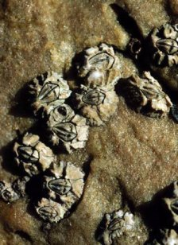

**Figure** 1: Six-plated barnacle

**Table** 1: Format of day.csv data files

| TREAT | BARNACLE |
| --- | --- |
| ALG1 | 27 |
| .. | .. |
| ALG2 | 24 |
| .. | .. |
| NB | 9 |
| .. | .. |
| S | 12 |
| .. | .. |

**Table** 2: Description of the variables in the day data file

| **TREAT** | Categorical listing of surface types. ALG1 = algal species 1, ALG2 = algal species 2, NB = naturally bare surface, S = scraped bare surface. |
| --- | --- |
| **BARNACLE** | The number of newly recruited barnacles on each plot after 4 weeks. |

# 3 Read in the data

```r
day <- read_csv("../data/day.csv", trim_ws = TRUE)
```

**glimpse**

```r
glimpse(day)
```

```
Rows: 20
Columns: 2
$ TREAT    <chr> "ALG1", "ALG1", "ALG1", "ALG1", "ALG1", "ALG2", "ALG2", "ALG2…
$ BARNACLE <dbl> 27, 19, 18, 23, 25, 24, 33, 27, 26, 32, 9, 13, 17, 14, 22, 12…
```

**head**

```r
## Explore the first 6 rows of the data
head(day)
```

```
# A tibble: 6 × 2
  TREAT BARNACLE
  <chr>    <dbl>
1 ALG1        27
2 ALG1        19
3 ALG1        18
4 ALG1        23
5 ALG1        25
6 ALG2        24
```

**str**

```r
str(day)
```

```
spc_tbl_ [20 × 2] (S3: spec_tbl_df/tbl_df/tbl/data.frame)
 $ TREAT   : chr [1:20] "ALG1" "ALG1" "ALG1" "ALG1" ...
 $ BARNACLE: num [1:20] 27 19 18 23 25 24 33 27 26 32 ...
 - attr(*, "spec")=
  .. cols(
  ..   TREAT = col_character(),
  ..   BARNACLE = col_double()
  .. )
 - attr(*, "problems")=<externalptr>
```

**Easystats (datawizard)**

```r
day |> datawizard::data_codebook()
```

```
day (20 rows and 2 variables, 2 shown)

ID | Name     | Type      | Missings |  Values |         N
---+----------+-----------+----------+---------+----------
1  | TREAT    | character | 0 (0.0%) |    ALG1 | 5 (25.0%)
   |          |           |          |    ALG2 | 5 (25.0%)
   |          |           |          |      NB | 5 (25.0%)
   |          |           |          |       S | 5 (25.0%)
---+----------+-----------+----------+---------+----------
2  | BARNACLE | numeric   | 0 (0.0%) | [8, 33] |        20
----------------------------------------------------------
```

**Skim (modelsummary)**

Unique

Missing Pct.

Mean

SD

Min

Median

Max

Histogram

BARNACLE

19

0

19.8

7.4

8.0

19.5

33.0

[figure not shown]

TREAT

N

%

ALG1

5

25.0

ALG2

5

25.0

NB

5

25.0

S

5

25.0

```r
day |> modelsummary::datasummary_skim()
```

TREAT

Unique

Missing Pct.

Mean

SD

Min

Median

Max

Histogram

BARNACLE

ALG1

5

0

22.4

3.8

18.0

23.0

27.0

[figure not shown]

ALG2

5

0

28.4

3.9

24.0

27.0

33.0

[figure not shown]

NB

5

0

15.0

4.8

9.0

14.0

22.0

[figure not shown]

S

5

0

13.2

4.5

8.0

12.0

20.0

[figure not shown]

TREAT

N

%

ALG1

5

25.0

ALG2

5

25.0

NB

5

25.0

S

5

25.0

```r
day |> modelsummary::datasummary_skim(by = "TREAT")
```

Start by declaring the categorical variables as factor.

```r
day <- day |> mutate(TREAT = factor(TREAT))
```

Model formula:
$$\begin{align}
y_i &\sim{} \mathcal{Pois}(\lambda_i)\\
ln(\mu_i) &= \boldsymbol{\beta} \bf{X_i}\\
\beta_0 &\sim{} \mathcal{N}(3.1, 0.3)\\
\beta_{1,2,3} &\sim{} \mathcal{N}(0,1)\\
\end{align}$$

where $\boldsymbol{\beta}$ is a vector of effects parameters and $\bf{X}$ is a model matrix representing the intercept and treatment contrasts for the effects of Treatment on barnacle recruitment.

# 4 Exploratory data analysis

The exploratory data analyses that we performed in the frequentist instalment of this example are equally valid here. That is, boxplots and/or violin plots for each population (substrate type).

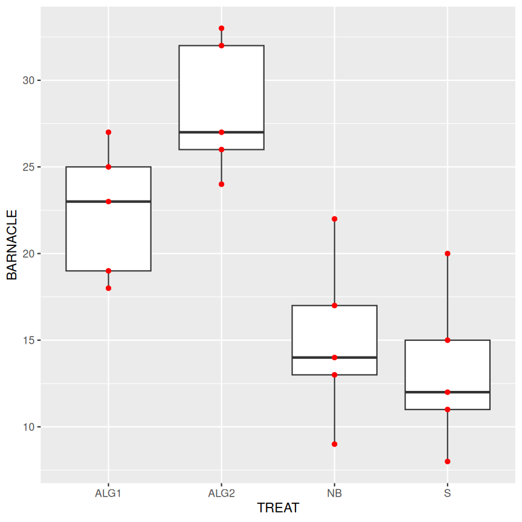

```r
day |> ggplot(aes(y = BARNACLE, x = TREAT)) +
  geom_boxplot() +
  geom_point(color = "red")
```

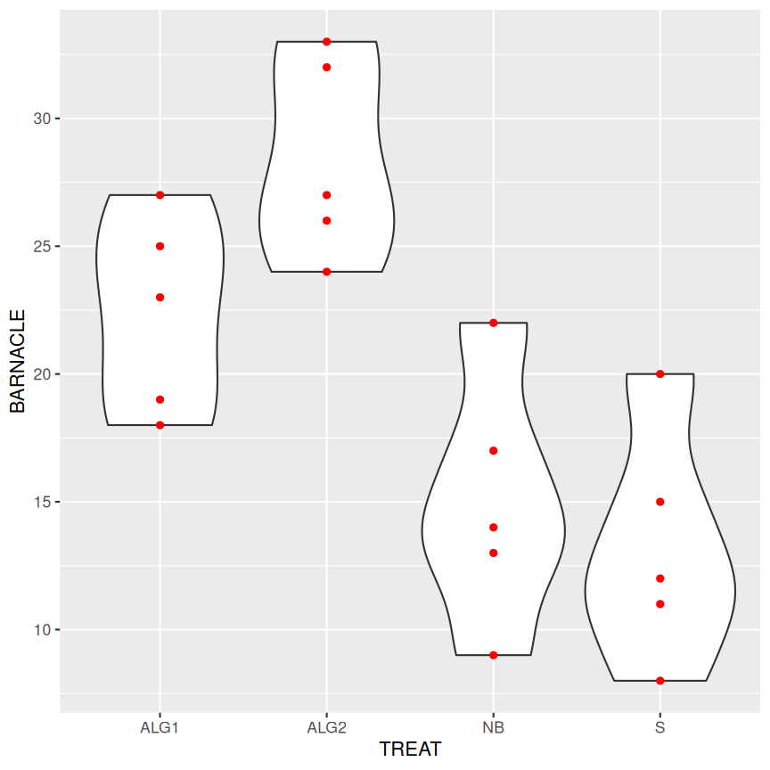

```r
day |> ggplot(aes(y = BARNACLE, x = TREAT)) +
  geom_violin() +
  geom_point(color = "red")
```

**Conclusions:**

- although exploratory data analysis suggests that we might well be fine modelling these data against a Gaussian distribution, a Poisson distribution would clearly be a more natural choice and it would also prevent any non positive predictions.

# 5 Fit the model

**rstanarm**

**Using default priors**

In `rstanarm`, the default priors are designed to be weakly informative. They are chosen to provide moderate regularisation (to help prevent over-fitting) and help stabilise the computations.

```r
day_rstanarm <- stan_glm(BARNACLE ~ TREAT,
  data = day,
  family = poisson(link = "log"),
  iter = 5000, warmup = 1000,
  chains = 3, thin = 5, refresh = 0
)
```

```r
prior_summary(day_rstanarm)
```

```
Priors for model 'day_rstanarm'
------
Intercept (after predictors centered)
 ~ normal(location = 0, scale = 2.5)

Coefficients
  Specified prior:
    ~ normal(location = [0,0,0], scale = [2.5,2.5,2.5])
  Adjusted prior:
    ~ normal(location = [0,0,0], scale = [5.63,5.63,5.63])
------
See help('prior_summary.stanreg') for more details
```

This tells us:

```r
2.5 / sd(model.matrix(~TREAT, day)[, 2])
```

```
[1] 5.627314
```

- there is no auxiliary prior as we are employing a Poisson distribution.

**Assessing priors**

One way to assess the priors is to have the MCMC sampler sample purely from the prior predictive distribution without conditioning on the observed data. Doing so provides a glimpse at the range of predictions possible under the priors. On the one hand, wide ranging predictions would ensure that the priors are unlikely to influence the actual predictions once they are conditioned on the data. On the other hand, if they are too wide, the sampler is being permitted to traverse into regions of parameter space that are not logically possible in the context of the actual underlying ecological context. Not only could this mean that illogical parameter estimates are possible, when the sampler is traversing regions of parameter space that are not supported by the actual data, the sampler can become unstable and have difficulty.

We can draw from the prior predictive distribution instead of conditioning on the response, by updating the model and indicating `prior_PD=TRUE`. After refitting the model in this way, we can plot the predictions to gain insights into the range of predictions supported by the priors alone.

```r
day_rstanarm1 <- update(day_rstanarm, prior_PD = TRUE)
```

```
Data points may overlap. Use the `jitter` argument to add some amount of
  random variation to the location of data points and avoid overplotting.
```

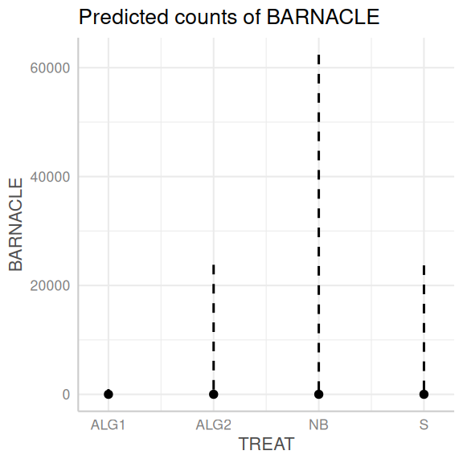

```r
day_rstanarm1 |>
  ggpredict() |>
  plot(show_data = TRUE)
```

```
Data points may overlap. Use the `jitter` argument to add some amount of
  random variation to the location of data points and avoid overplotting.
```

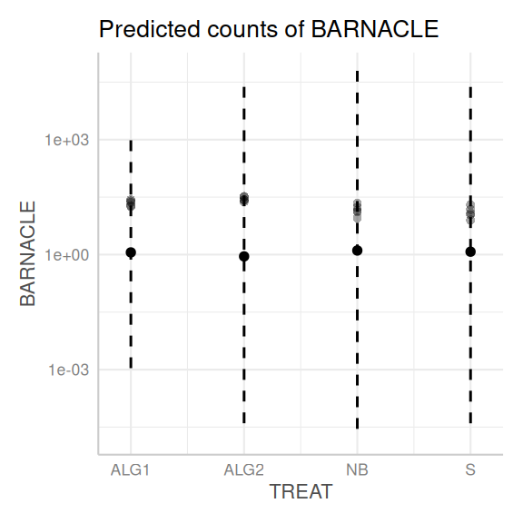

```r
ggpredict(day_rstanarm1) |>
  plot(show_data = TRUE) |>
  wrap_plots() &
  scale_y_log10()
```

**Conclusions:**

- we see that the range of predictions is fairly wide and the predicted means could range from 0 to very large (perhaps too large).

**Defining priors**

The following link provides some guidance about defining priors. [https://github.com/stan-dev/stan/wiki/Prior-Choice-Recommendations]

When defining our own priors, we typically do not want them to be scaled.

If we wanted to define our own priors that were less vague, yet still not likely to bias the outcomes, we could try the following priors (mainly plucked out of thin air):

I will also overlay the raw data for comparison.

```r
day_rstanarm2 <- stan_glm(BARNACLE ~ TREAT,
  data = day,
  family = poisson(link = "log"),
  prior_intercept = normal(3, 1, autoscale = FALSE),
  prior = normal(0, 1, autoscale = FALSE),
  prior_PD = TRUE,
  iter = 5000, warmup = 1000,
  chains = 3, thin = 5, refresh = 0
)
```

```
Data points may overlap. Use the `jitter` argument to add some amount of
  random variation to the location of data points and avoid overplotting.
```

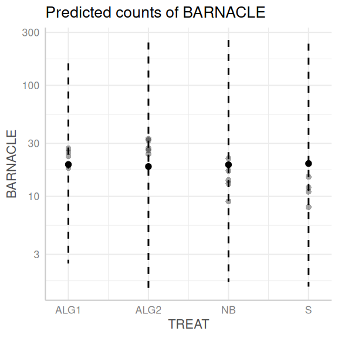

```r
ggpredict(day_rstanarm2) |>
  plot(show_data = TRUE) +
  scale_y_log10()
```

Now lets refit, conditioning on the data.

```r
day_rstanarm3 <- update(day_rstanarm2, prior_PD = FALSE)
```

**Plotting prior and posterior**

```
Drawing from prior...
```

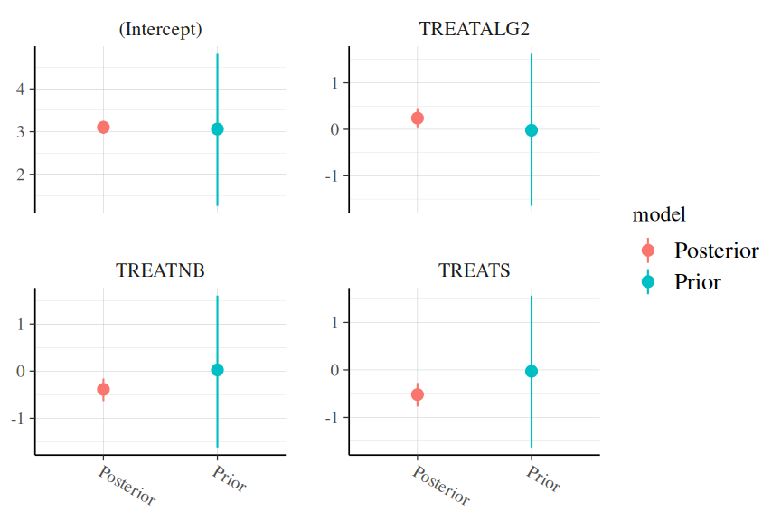

```r
posterior_vs_prior(day_rstanarm3,
  color_by = "vs", group_by = TRUE,
  facet_args = list(scales = "free_y")
)
```

**Conclusions:**

- in each case, the prior is substantially wider than the posterior, suggesting that the posterior is not biased towards the prior.

```
Data points may overlap. Use the `jitter` argument to add some amount of
  random variation to the location of data points and avoid overplotting.
```

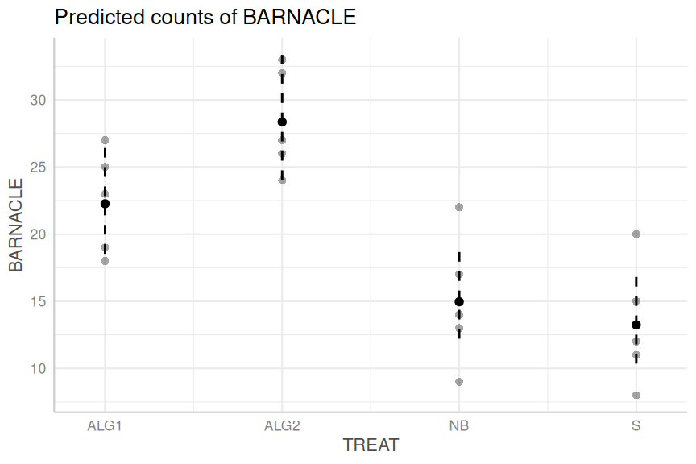

```r
ggpredict(day_rstanarm3) |> plot(show_data = TRUE)
```

**brms**

**Using default priors**

In `brms`, the default priors are designed to be weakly informative. They are chosen to provide moderate regularisation (to help prevent over-fitting) and help stabilise the computations.

Unlike `rstanarm`, `brms` models must be compiled before they start sampling. For most models, the compilation of the stan code takes around 45 seconds.

```r
day_form <- bf(BARNACLE ~ TREAT,
  family = poisson(link = "log")
)
day_brm <- brm(day_form,
  data = day,
  iter = 5000,
  warmup = 2500,
  chains = 3, cores = 3,
  thin = 5,
  refresh = 0,
  backend = "rstan"
)
```

```r
day_brm |> prior_summary()
```

```
                prior     class      coef group resp dpar nlpar lb ub       source
               (flat)         b                                            default
               (flat)         b TREATALG2                             (vectorized)
               (flat)         b   TREATNB                             (vectorized)
               (flat)         b    TREATS                             (vectorized)
 student_t(3, 3, 2.5) Intercept                                            default
```

**Assessing priors**

**ggpredict**

```
Data points may overlap. Use the `jitter` argument to add some amount of
  random variation to the location of data points and avoid overplotting.
```

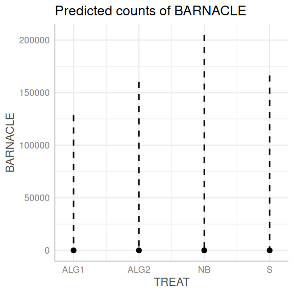

```r
day_brm1 |>
  ggpredict() |>
  plot(show_data = TRUE)
```

```
Data points may overlap. Use the `jitter` argument to add some amount of
  random variation to the location of data points and avoid overplotting.
```

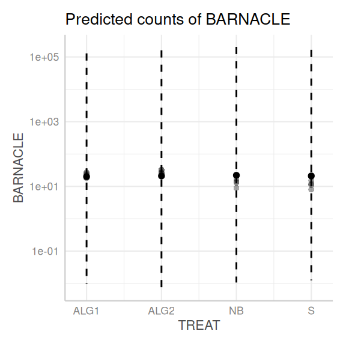

```r
day_brm1 |>
  ggpredict() |>
  plot(show_data = TRUE) |>
  wrap_plots() &
  scale_y_log10()
```

**ggemmeans**

```
Data points may overlap. Use the `jitter` argument to add some amount of
  random variation to the location of data points and avoid overplotting.
```

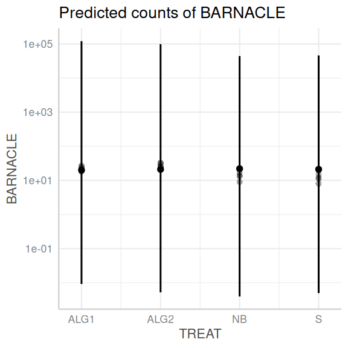

```r
day_brm1 |>
  ggemmeans(~TREAT) |>
  plot(show_data = TRUE) +
  scale_y_log10()
```

**conditional_effects**

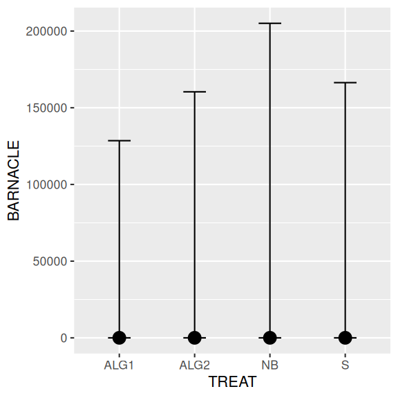

```r
day_brm1 |>
  conditional_effects() |>
  plot(points = TRUE)
```

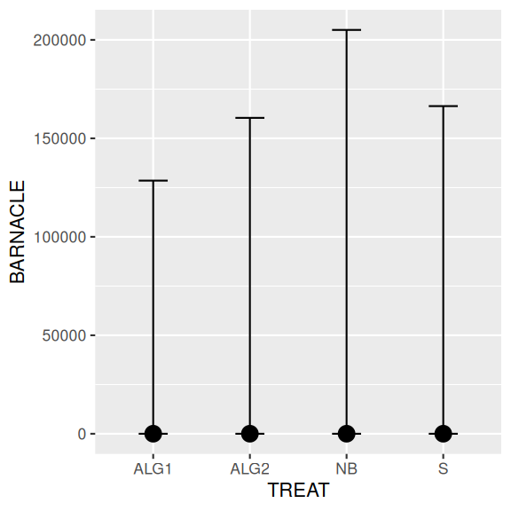

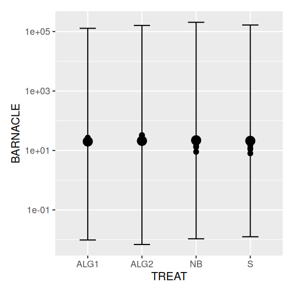

```r
day_brm1 |>
  conditional_effects() |>
  plot(points = TRUE) |>
  wrap_plots() &
  scale_y_log10()
```

**Conclusions:**

- we see that the range of predictions is fairly wide (ranging from 0 to very high)

**Defining priors**

**ggpredict**

```
Data points may overlap. Use the `jitter` argument to add some amount of
  random variation to the location of data points and avoid overplotting.
```

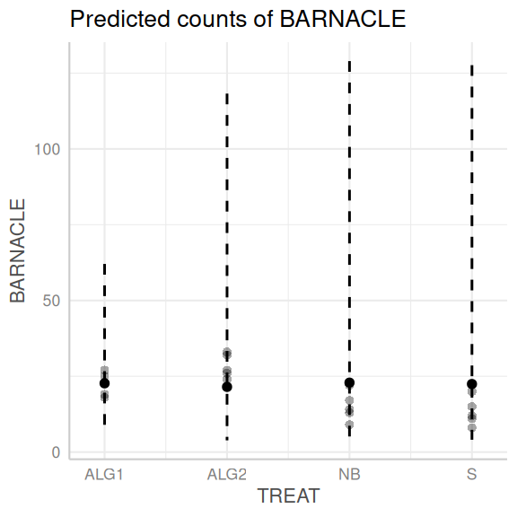

```r
day_brm2 |>
  ggpredict() |>
  plot(show_data = TRUE)
```

```
Data points may overlap. Use the `jitter` argument to add some amount of
  random variation to the location of data points and avoid overplotting.
```

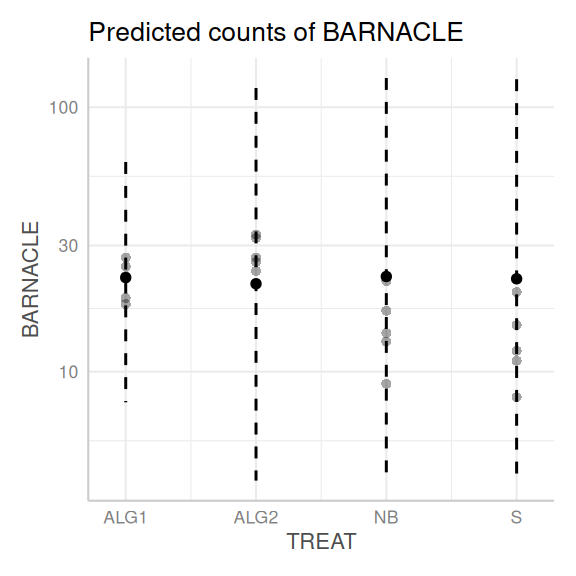

```r
day_brm2 |>
  ggpredict() |>
  plot(show_data = TRUE) |>
  wrap_plots() &
  scale_y_log10()
```

**ggemmeans**

```
Data points may overlap. Use the `jitter` argument to add some amount of
  random variation to the location of data points and avoid overplotting.
```

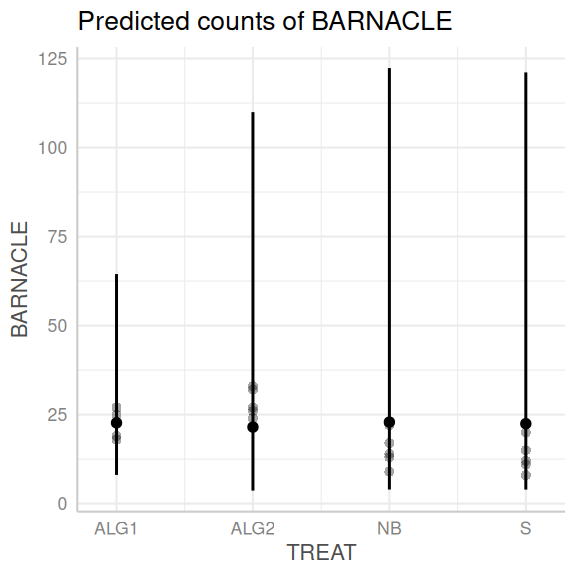

```r
day_brm2 |>
  ggemmeans(~TREAT) |>
  plot(show_data = TRUE)
```

```
Data points may overlap. Use the `jitter` argument to add some amount of
  random variation to the location of data points and avoid overplotting.
```

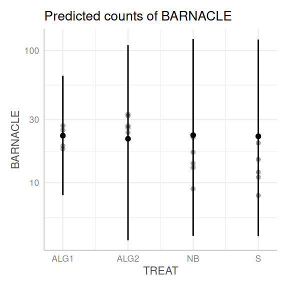

```r
day_brm2 |>
  ggemmeans(~TREAT) |>
  plot(show_data = TRUE) |>
  wrap_plots() &
  scale_y_log10()
```

**conditional_effects**

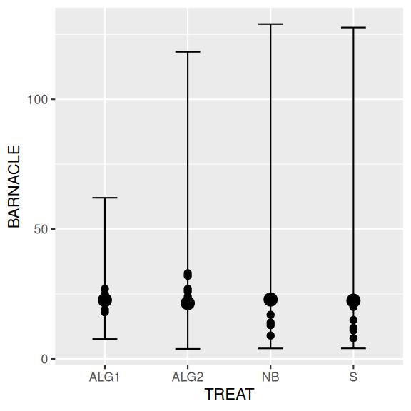

```r
day_brm2 |>
  conditional_effects() |>
  plot(points = TRUE)
```

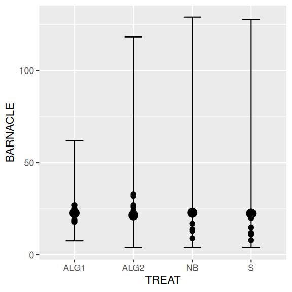

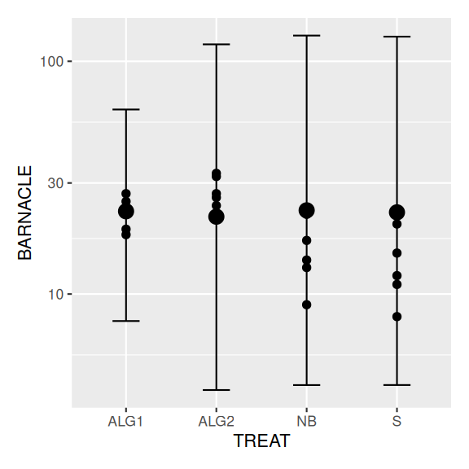

```r
day_brm2 |>
  conditional_effects() |>
  plot(points = TRUE) |>
  wrap_plots() &
  scale_y_log10()
```

```r
day_brm3 <- day_brm2 |> update(sample_prior = "yes", refresh = 0)
```

```
The desired updates require recompiling the model
```

**Plotting prior and posterior**

```r
day_brm3 |> get_variables()
```

```
 [1] "b_Intercept"     "b_TREATALG2"     "b_TREATNB"       "b_TREATS"
 [5] "Intercept"       "prior_Intercept" "prior_b"         "lprior"
 [9] "lp__"            "accept_stat__"   "stepsize__"      "treedepth__"
[13] "n_leapfrog__"    "divergent__"     "energy__"
```

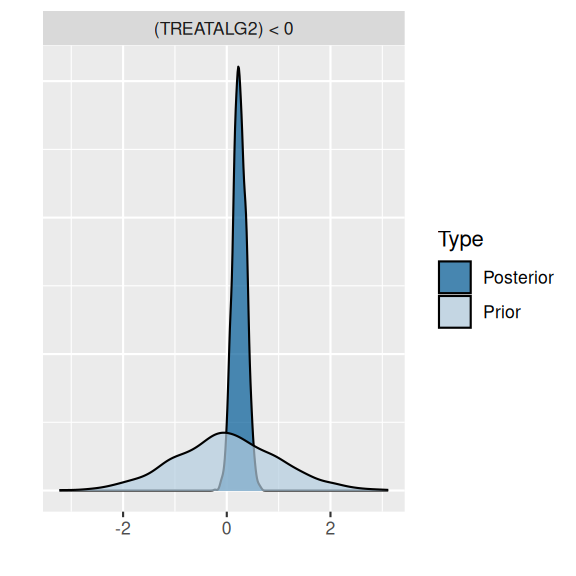

```r
day_brm3 |>
  hypothesis("TREATALG2<0") |>
  plot()
```

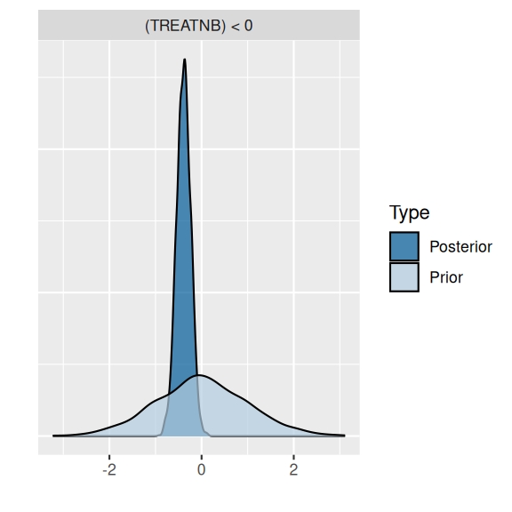

```r
day_brm3 |>
  hypothesis("TREATNB<0") |>
  plot()
```

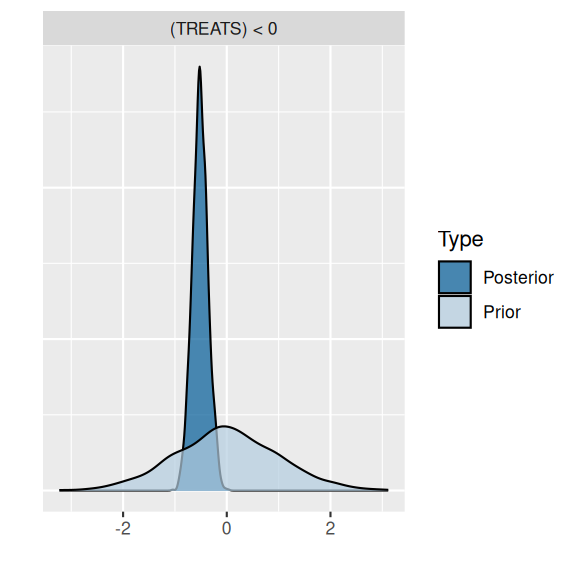

```r
day_brm3 |>
  hypothesis("TREATS<0") |>
  plot()
```

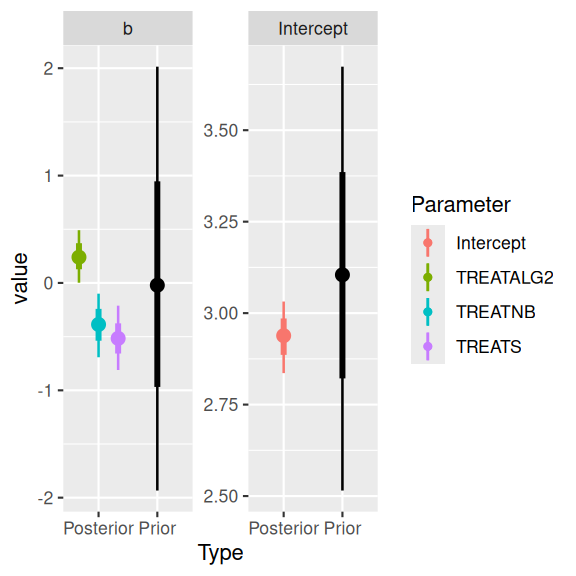

```r
day_brm3 |> SUYR_prior_and_posterior()
```

**Exploring the stan code**

```r
day_brm3 |> standata()
```

```
$N
[1] 20

$Y
 [1] 27 19 18 23 25 24 33 27 26 32  9 13 17 14 22 12  8 15 20 11

$K
[1] 4

$Kc
[1] 3

$X
   Intercept TREATALG2 TREATNB TREATS
1          1         0       0      0
2          1         0       0      0
3          1         0       0      0
4          1         0       0      0
5          1         0       0      0
6          1         1       0      0
7          1         1       0      0
8          1         1       0      0
9          1         1       0      0
10         1         1       0      0
11         1         0       1      0
12         1         0       1      0
13         1         0       1      0
14         1         0       1      0
15         1         0       1      0
16         1         0       0      1
17         1         0       0      1
18         1         0       0      1
19         1         0       0      1
20         1         0       0      1
attr(,"assign")
[1] 0 1 1 1
attr(,"contrasts")
attr(,"contrasts")$TREAT
     ALG2 NB S
ALG1    0  0 0
ALG2    1  0 0
NB      0  1 0
S       0  0 1


$prior_only
[1] 0

attr(,"class")
[1] "standata" "list"
```

```r
day_brm3 |> stancode()
```

```
// generated with brms 2.22.0
functions {
}
data {
  int<lower=1> N;  // total number of observations
  array[N] int Y;  // response variable
  int<lower=1> K;  // number of population-level effects
  matrix[N, K] X;  // population-level design matrix
  int<lower=1> Kc;  // number of population-level effects after centering
  int prior_only;  // should the likelihood be ignored?
}
transformed data {
  matrix[N, Kc] Xc;  // centered version of X without an intercept
  vector[Kc] means_X;  // column means of X before centering
  for (i in 2:K) {
    means_X[i - 1] = mean(X[, i]);
    Xc[, i - 1] = X[, i] - means_X[i - 1];
  }
}
parameters {
  vector[Kc] b;  // regression coefficients
  real Intercept;  // temporary intercept for centered predictors
}
transformed parameters {
  real lprior = 0;  // prior contributions to the log posterior
  lprior += normal_lpdf(b | 0, 1);
  lprior += normal_lpdf(Intercept | 3.1, 0.3);
}
model {
  // likelihood including constants
  if (!prior_only) {
    target += poisson_log_glm_lpmf(Y | Xc, Intercept, b);
  }
  // priors including constants
  target += lprior;
}
generated quantities {
  // actual population-level intercept
  real b_Intercept = Intercept - dot_product(means_X, b);
  // additionally sample draws from priors
  real prior_b = normal_rng(0,1);
  real prior_Intercept = normal_rng(3.1,0.3);
}
```